# Final Report

Ryan Innamorati, Nathan Stanley, Cameron Stivers, Ben Laufer

3/9/2022

The Internet has arguably been the most influential development of humanity in modern times. Throughout countries across the world, it has broadened the limits of what free speech can be, reconnected friends and family across borders, and allowed individuals and academics alike to share information and further their knowledge on the world around us. In this era of constant connection, communication, and available information, one would assume that there exists some semblance of correlation between general happiness and access to the Internet, whether it be positive or negative.

Throughout this report, we attempt to investigate the possibility of a relationship between two variables measured in countries around the world: overall happiness score (on a scale from zero to one hundred) and percentage of population with access to the Internet. We then delve further into the quality of said relationship, using statistical visualizations and indicators to determine whether or not any perceived correlation is reliable.

```r
library(tidyverse)
library(broom)
library(gapminder)
library(gganimate)
library(av)
library(countrycode)
library(kableExtra)
library(png)
library(gifski)
```

## Data Cleaning

In order to investigate this relationship, first we must combine two datasets together and get both variables into one place from which we can begin our analysis. By including regions in our final dataset, we introduce the possibility of viewing correlation results by location, bringing in the question of whether or not these happiness scores can be affected by variables other than the single one we are investigating.

```r
happy <- read_csv(here::here("project", "data", "hapiscore_whr.csv"))
non_internet <- read_csv(here::here("project", "data", "non_net_users_prc.csv"))

happy_long <- happy %>%
  pivot_longer(`2004`:`2018`, names_to = "year", values_to = "h_score")

non_int_long <- non_internet %>%
  pivot_longer(`1989`:`2018`, names_to = "year", values_to = "n_intprop")

happy_int <- happy_long %>%
  merge(non_int_long, by = c("country", "year")) %>%
  mutate(
    n_intprop = 100 - n_intprop
  ) %>%
  rename(intprop = n_intprop)

happy_clean <- happy_int %>%
  mutate(
    continent = countrycode(sourcevar = happy_int[, "country"],
                            origin = "country.name",
                            destination = "continent")
  ) %>%
  filter(!is.na(h_score))
```

## Data Visualization

### Relationship Between Variables (colored by Region)

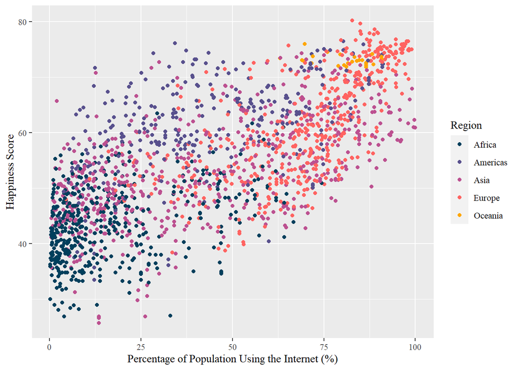

```r
happy_clean %>%
  ggplot(aes(x = intprop, y = h_score)) +
  geom_point(aes(color = continent)) +
  xlab("Percentage of Population Using the Internet (%)") +
  ylab("Happiness Score") +
  theme(
    text = element_text(family = "serif")
  ) +
  scale_color_manual(values = c("#003f5c", "#58508d", "#bc5090", "#ff6361", "#ffa600"), name = "Region")
```

### Relationship Between Variables Over Time (colored by Region)

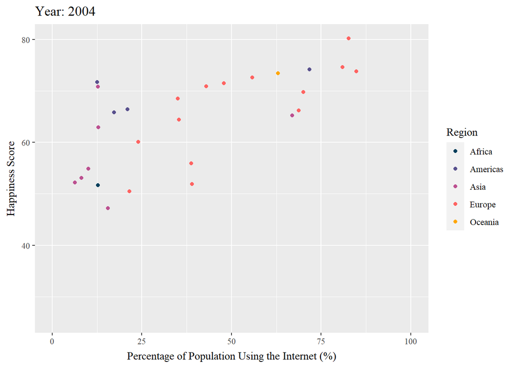

```r
happy_clean %>%
  ggplot(aes(x = intprop, y = h_score)) +
  geom_point(aes(color = continent)) +
  xlab("Percentage of Population Using the Internet (%)") +
  ylab("Happiness Score") +
  labs(title = "Year: {current_frame}") +
  theme(
    text = element_text(family = "serif")
  ) +
  scale_color_manual(values = c("#003f5c", "#58508d", "#bc5090", "#ff6361", "#ffa600"), name = "Region") +
  #facet_wrap(~ continent) +
  transition_manual(year)
```

## Linear Regression

In order to further investigate the relationship between our explanatory (percentage of population with access to Internet) and response (overall happiness score) variables, we define a simple linear regression. From the summary output below, we can present our model using the following equation where `h_score` is the overall happiness score and `intprop` is the percentage of the population with access to Internet:

$$\begin{equation}
\widehat{h\_score}_i = 43.03 + 0.2635 intprop_i
\end{equation}$$

We can interpret the intercept of 43.03 as saying that if none of a country’s population had access to the Internet, the expected happiness score would be 43.03. The intprop coefficient of 0.2635 can be interpreted as saying that each percentage point increase in Internet access is associated with an increase of 0.2635 in the mean average happiness score.

```r
happy_lm <- happy_clean %>%
  lm(formula = h_score ~ intprop, data = .)

coef <- data.frame(summary(happy_lm)$coefficients) %>%
  select(Estimate)

knitr::kable(coef) %>%
  kable_styling(font_size = 15, html_font = "serif") %>%
  row_spec(0:2, color = "black", background = "white")
```

|  | Estimate |
| --- | --- |
| (Intercept) | 43.0299711 |
| intprop | 0.2635078 |

### Model Fit

To get more information on how good of a fit this simple linear regression model really is for our data, we produce the variance numbers for the response values, fitted values, and the residuals from the estimated model. The magnitudes of these numbers should give us a good idea of how much the different aspects of our model vary from each other on average.

```r
res_var <- var(happy_clean$h_score)
fit_var <- happy_lm %>%
  augment() %>%
  select(`.fitted`) %>%
  var() %>%
  as.numeric()
resid_var <- happy_lm %>%
  augment() %>%
  select(`.resid`) %>%
  var() %>%
  as.numeric()

var_df <- data.frame(res_var, fit_var, resid_var) %>%
  rename(
    "Variance in Response Values" = res_var,
    "Variance in Fitted Regression Values" = fit_var,
    "Variance in Regression Residuals" = resid_var
  )

knitr::kable(var_df) %>%
  kable_styling(font_size = 15, html_font = "serif") %>%
  row_spec(0:1, color = "black", background = "white")
```

| Variance in Response Values | Variance in Fitted Regression Values | Variance in Regression Residuals |
| --- | --- | --- |
| 126.6104 | 62.04147 | 64.5689 |

From the table above, we can see that there is a substantial amount of variance in the response values of our regression model. This would suggest that our single explanatory variable does not completely explain all the variance in our model, and therefore the quality of the model can be defined as incomplete. This information aligns with the assumptions we made earlier about the effects that the possible inclusion of additional variables (like region) could have on the accuracy of our model.

## Visualizing Simulations from the Model

Thus far, our results show that our model is not the greatest fit for explaining the response variable. To investigate this claim further, we apply the use of a predictive check in which we simulate a data set based off of our model that maintains the same error values as our original data set and compare the observed data to the simulated data. If our model is a good fit for the data and explanatory variables, then the simulated and observed data should be extremely similar.

### Simulated Data alongside Observed Data

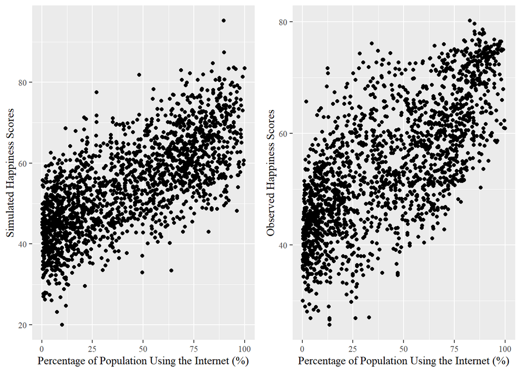

```r
noise <- function(x, mean = 0, sd){
  x + rnorm(length(x),
            mean,
            sd)
}

happy_predict <- predict(happy_lm)
happy_sigma <- sigma(happy_lm)

new_data <- tibble(sim_happy = noise(happy_predict,
                                     sd = happy_sigma
                                     )
                   )
plot_data <- bind_cols(happy_clean, new_data)

obs <- plot_data %>%
  ggplot(aes(x = intprop, y = h_score)) +
  geom_point() +
  ylab("Observed Happiness Scores") +
  xlab("Percentage of Population Using the Internet (%)") +
  theme(
    text = element_text(family = "serif")
  )

sim <- plot_data %>%
  ggplot(aes(x = intprop, y = sim_happy)) +
  geom_point() +
  ylab("Simulated Happiness Scores") +
  xlab("Percentage of Population Using the Internet (%)") +
  theme(
    text = element_text(family = "serif")
  )

gridExtra::grid.arrange(sim, obs, nrow = 1)
```

### Relationship Between Observed and Simulated Happiness Scores

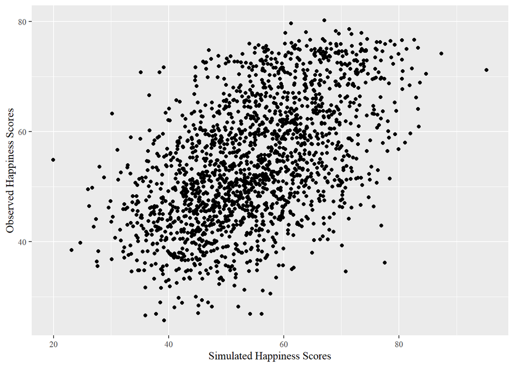

```r
plot_data %>%
  ggplot(aes(x = sim_happy, y = h_score)) +
  geom_point() +
  xlab("Simulated Happiness Scores") +
  ylab("Observed Happiness Scores") +
  theme(
    text = element_text(family = "serif")
  )
```

## Generating Multiple Predictive Checks

To further investigate the fit of our model using our simulated and observed data, we can make use of the $R^2$ summary statistic. Here, we generate 1000 different simulations of our response variable in order to get a good picture as to how statistically accurate our model is. We then plot the distribution of $R^2$ values from these simulations to show how accurate our model is on average.

```r
nsims <- 1000

sims <- map_dfc(1:nsims,
                ~ tibble(sim = noise(happy_predict, sd = happy_sigma)
                        )
                )
colnames(sims) <- colnames(sims) %>%
  str_replace(pattern = "\\.\\.\\.", replace = "_")

sims <- happy_clean %>%
  filter(!is.na(h_score),
         !is.na(intprop),
         !is.na(continent)) %>%
  select(h_score) %>%
  bind_cols(sims)

sim_r_sq <- sims %>%
  map(~lm(h_score ~ .x, data = sims)) %>%
  map(glance) %>%
  map_dbl(~.$r.squared)

sim_rsq <- as.tibble(sim_r_sq)
```

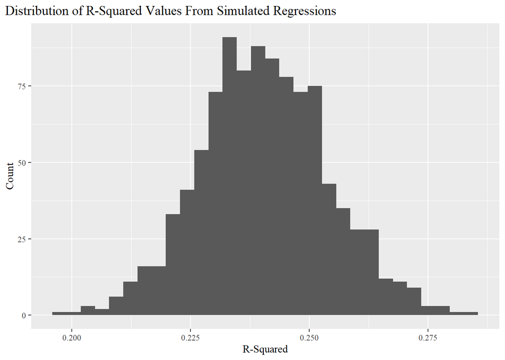

```r
sim_rsq %>%
  filter(value < 1) %>%
  ggplot(aes(x = value)) +
  geom_histogram() +
  labs(title = "Distribution of R-Squared Values From Simulated Regressions") +
  xlab("R-Squared") +
  ylab("Count") +
  theme(
    plot.title.position = "plot",
    text = element_text(family = "serif")
  )
```

## Conclusion

As the above results show, while there does appear to be a relationship and some correlation between happiness scores and Internet access across the world, it is not a very strong relationship. If we were to add more variables and perhaps try different models, we might be able to find more reliable predictors for happiness score. However, it is unlikely that we would ever find a perfect predictor for this variable. Happiness is one of the most subjective things one could possibly attempt to predict or measure, and is an individualized emotion that could never be properly estimated or quantified. The effect that Internet access can have on happiness is truly up to the individual, but the process of attempting to predict an unquantifiable aggregate variable is interesting nonetheless.